# Visualising AMR data effectively

AMR Research Forum

Sara Burgess

21 September 2026

## About me

- Microbiologist and data visualisation consultant
- Academic and industry experience in microbiology and genomics
- PhD in Microbiology
- Certificate in Applied Statistics and self taught data visualisation specialist
- Part-time research officer in the mEpiLab, School of Veterinary Science, Massey University

## My research

Sources and transmission pathways of antimicrobial resistant *E. coli*

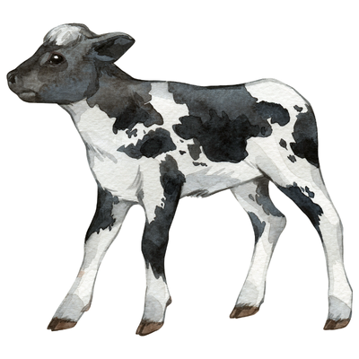

Impact of waste milk feeding

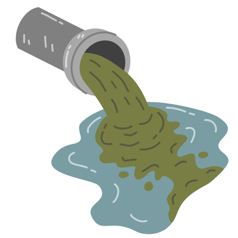

ESBL-Ec from humans and waterways

[figure not shown]

Environmental AMR surveillance

## The Visual Dictionary

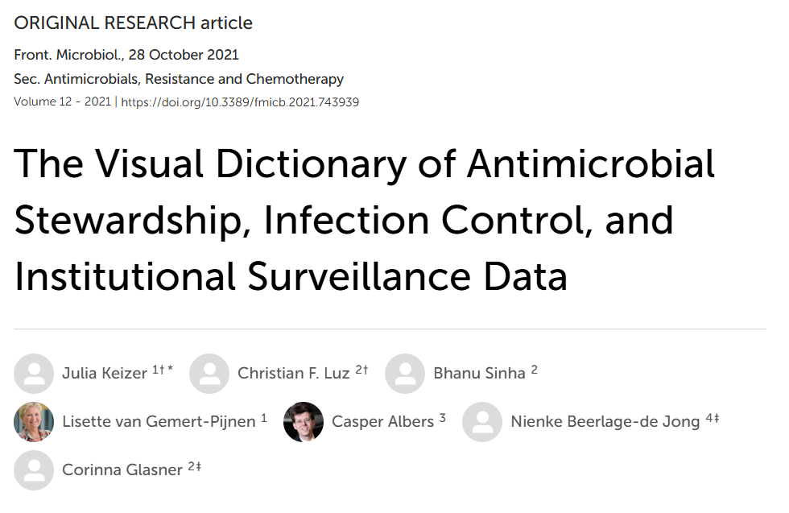

## The Visual Dictionary

- 150 visualisations analysed
- 44% required additional text to explain visual
- dual y axes
- inconsistent colour schemes
- incorrect graph choice
- hidden data points
- “chart junk”

## Understand your audience and context

- Other scientists
- Clients
- Health professionals
- Government agencies
- General public

How will you convey your message to your audience?

What is the key message?

## Presenting data clearly

No clutter

## Presenting data clearly

Colour effectively

## Presenting data clearly

Reduce eye movement

## Presenting data clearly

Clear takeaway message

## Presenting data clearly

Text hierarchy

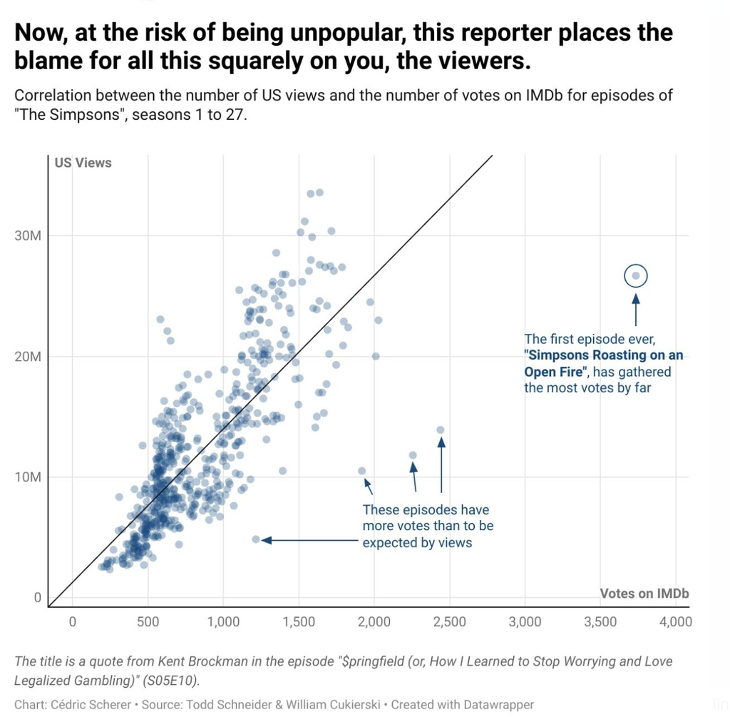

## Presenting data clearly

Annotations

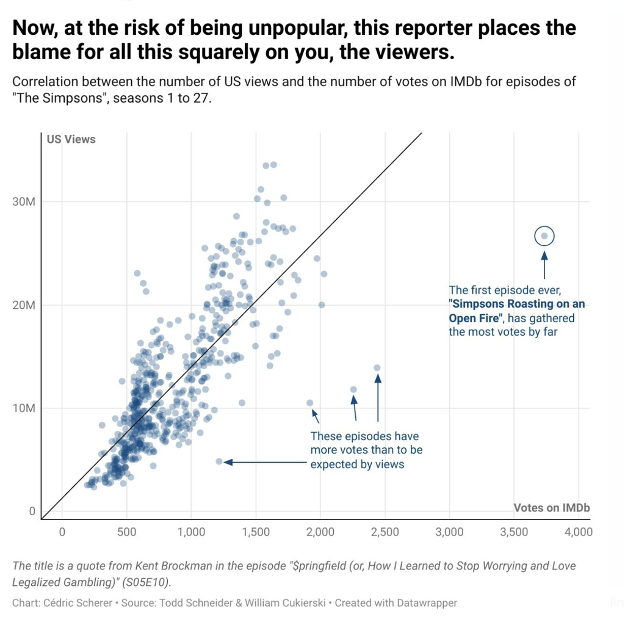

## Makeover

Pre- and Post-COVID-19 Antimicrobial Resistance Pattern of Pathogens in an Intensive Care Unit

## Makeover - declutter

## Makeover - colour effectively

## Makeover - colour effectively

- Colour with purpose [image color picker](https://imagecolorpicker.com/)

[figure not shown]

## Makeover - colour effectively

- Colour with purpose [image color picker](https://imagecolorpicker.com/)
- Use accessible colour palettes

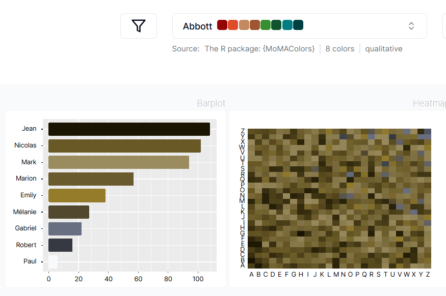

Image source: [R Graph Gallery, Colour Palette Finder](https://r-graph-gallery.com/color-palette-finder)

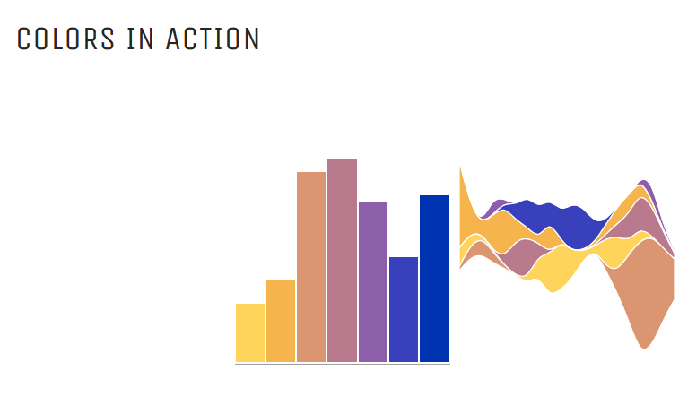

Image source: [Viz Palette, Susie Lu](https://projects.susielu.com/viz-palette)

- Less is more

## Makeover - colour effectively

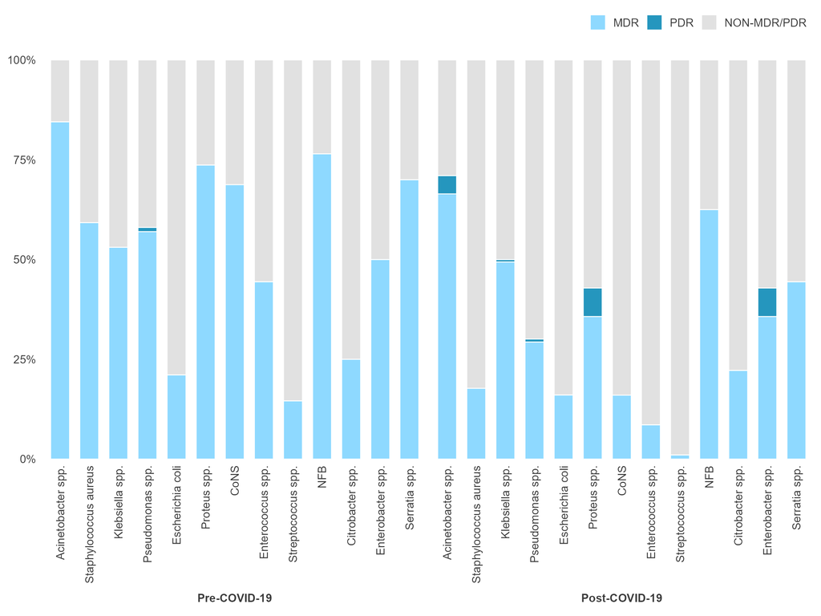

## Makeover - reduce eye movement

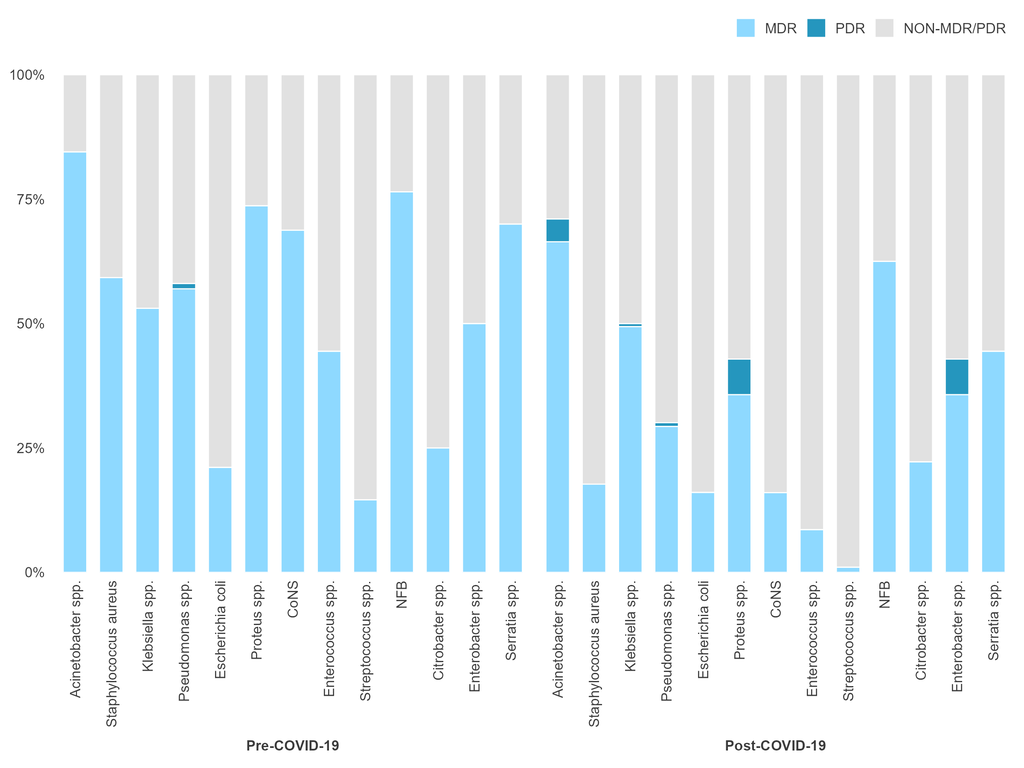

## Makeover - reduce eye movement

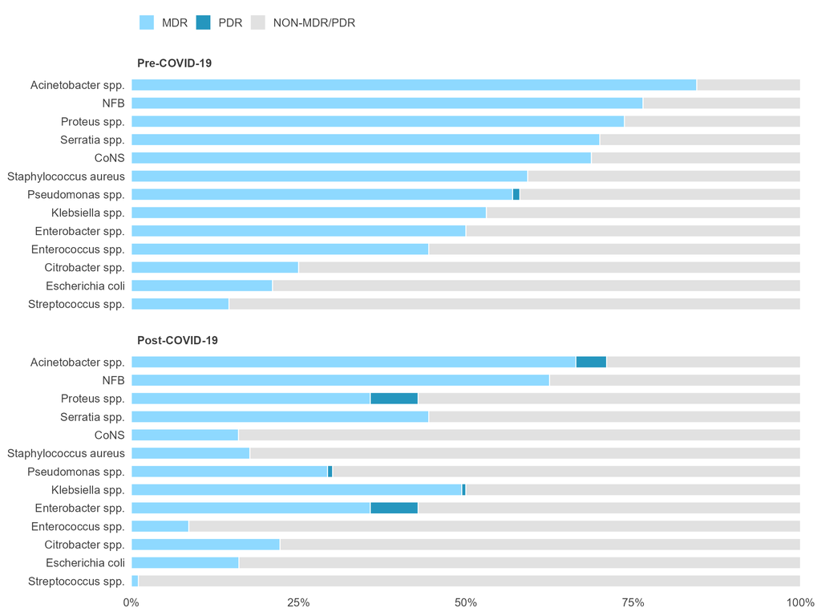

## Makeover - clear message

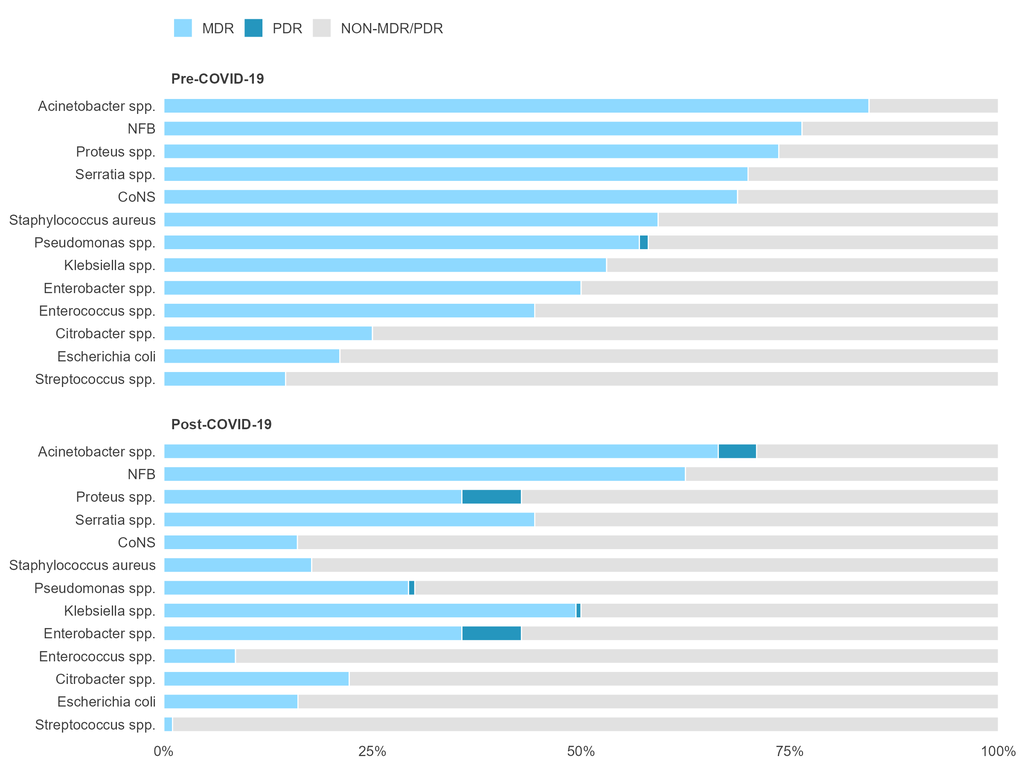

## Makeover - clear message

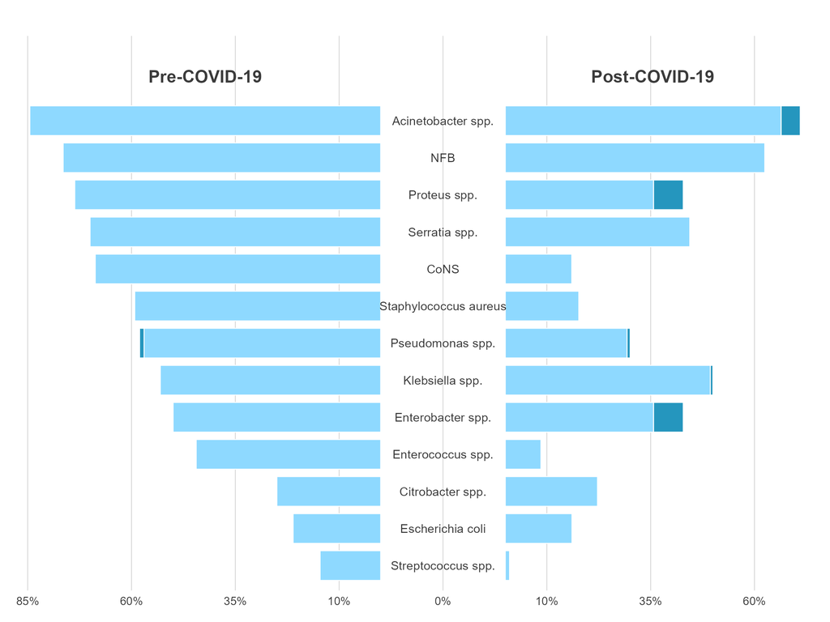

## Makeover - clear message

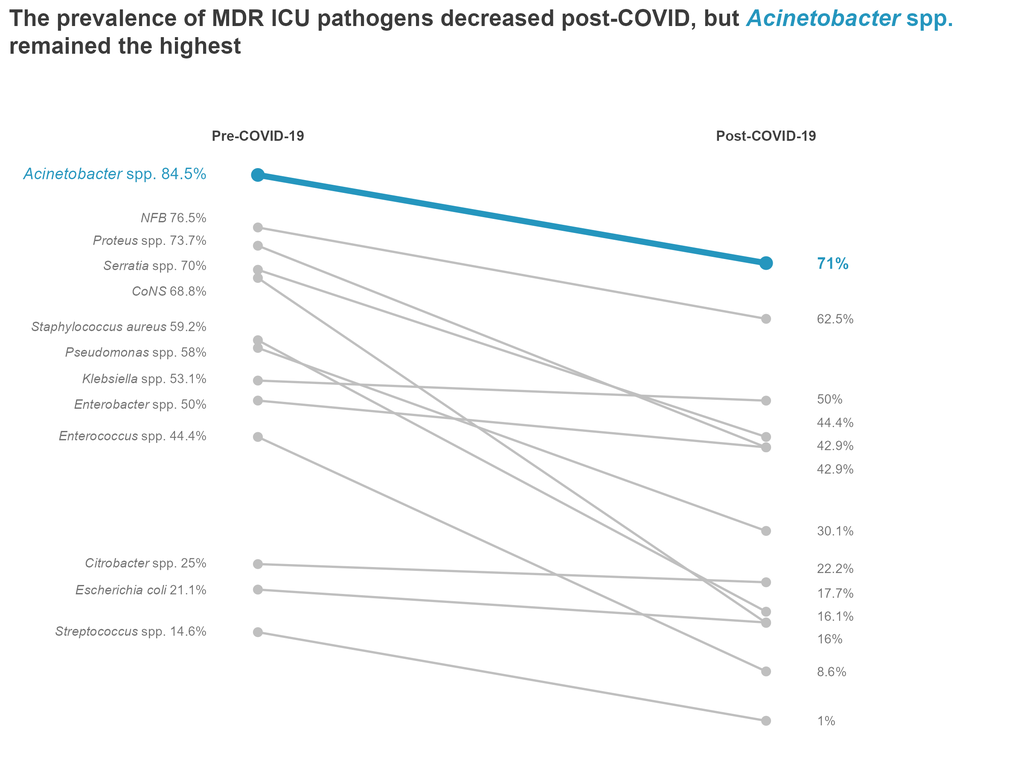

## Makeover

Before

[figure not shown]

After

## Graph alternatives

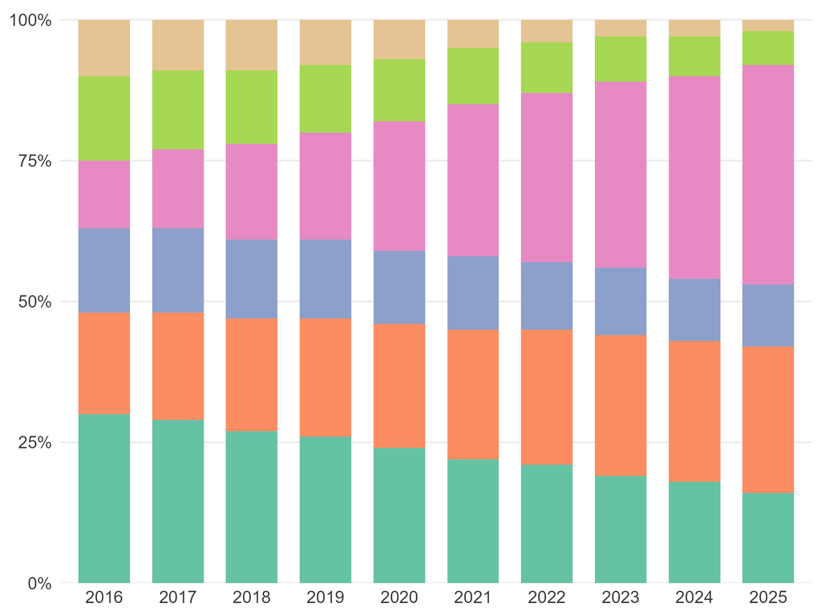

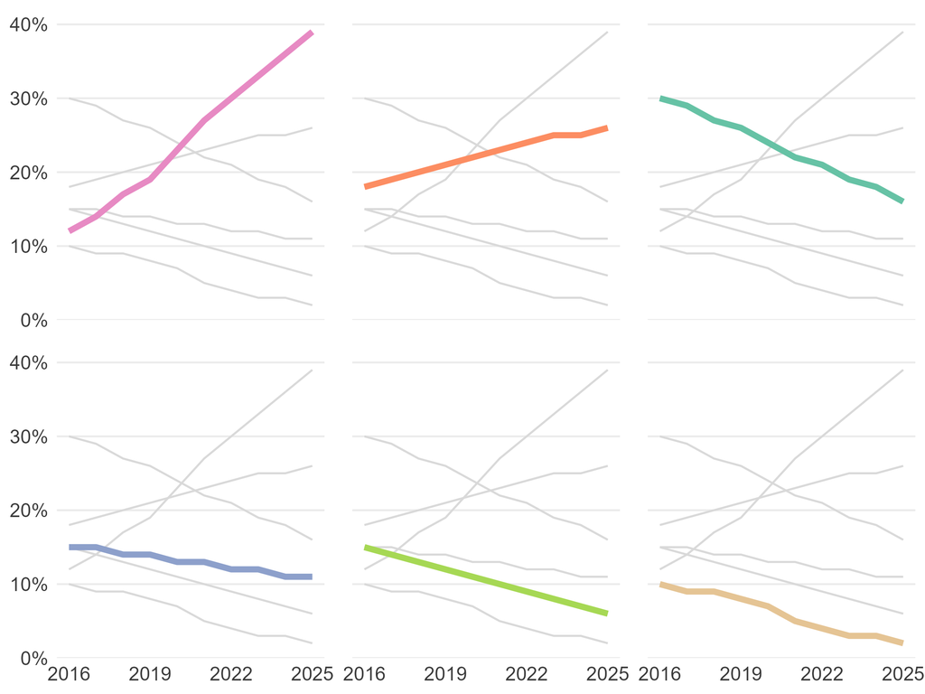

## Graph alternatives

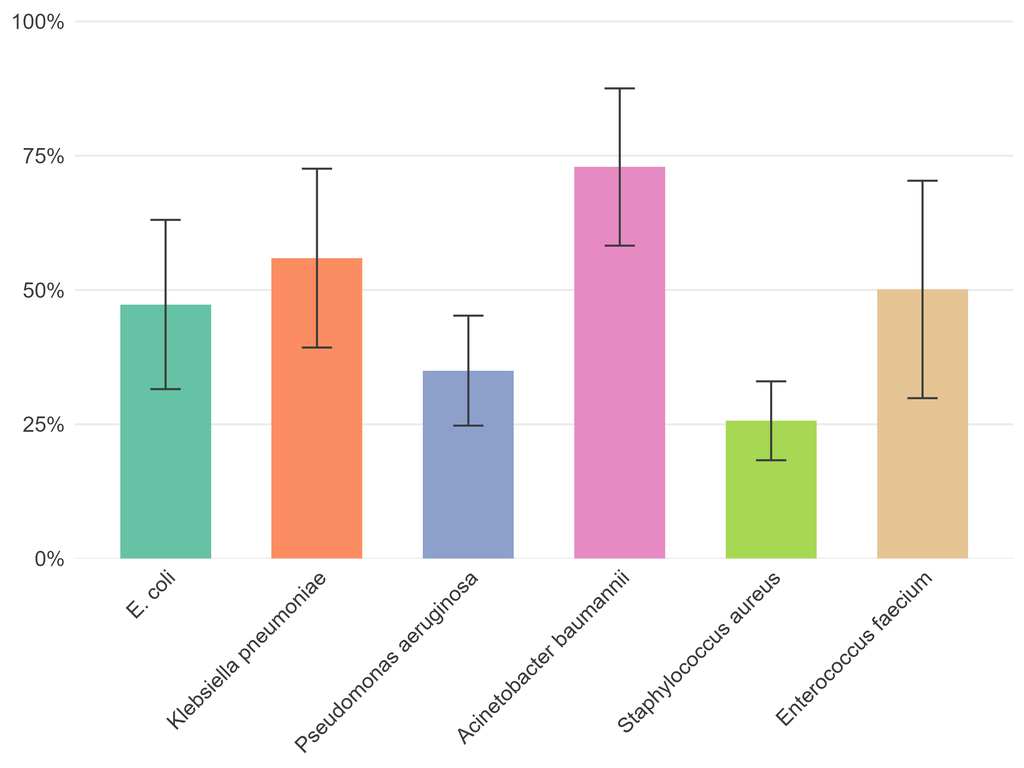

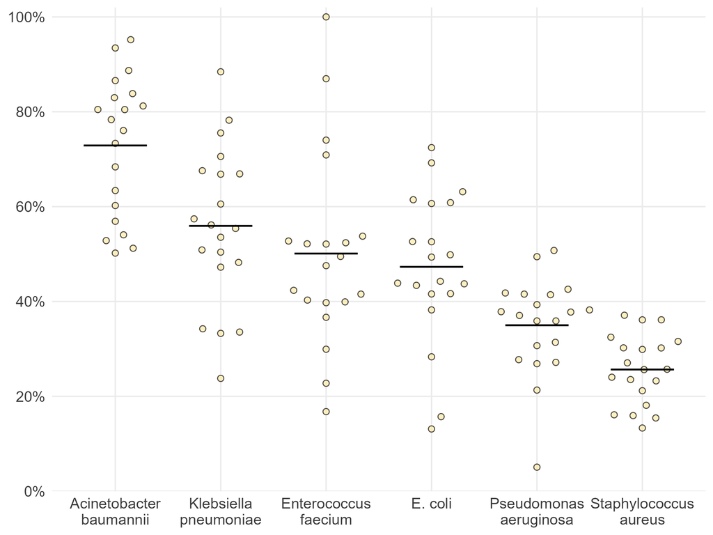

## Graph alternatives

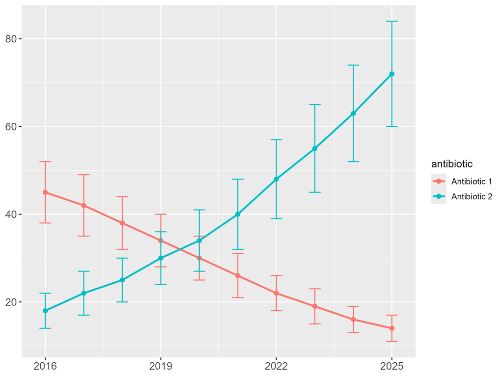

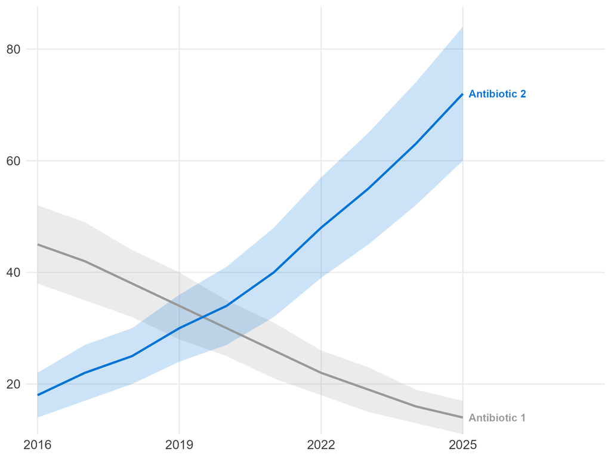

## Graph alternatives

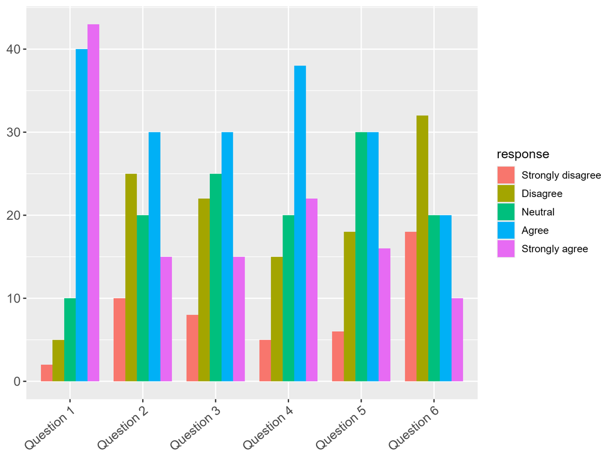

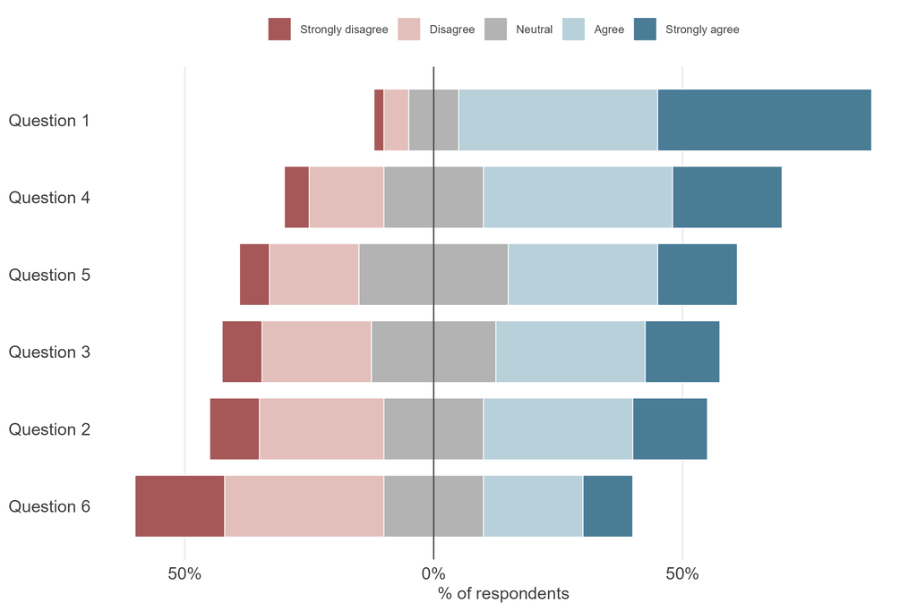

## Graph alternatives

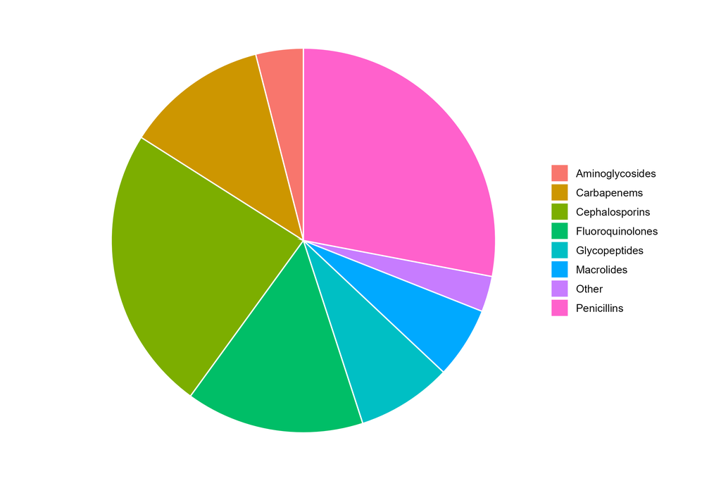

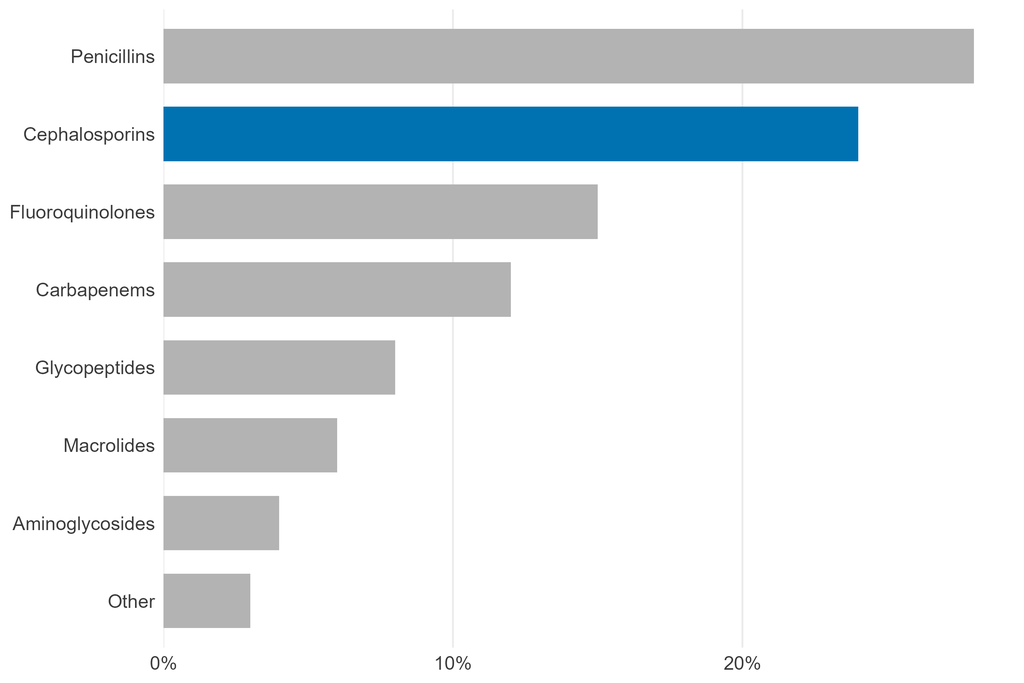

## Resources

- [Storytelling with Data](https://www.storytellingwithdata.com/)
- [From data to viz](https://www.data-to-viz.com/#explore)
- [R Graph Gallery - Top R Graph Examples](https://r-graph-gallery.com/best-r-chart-examples.html)

## Summary

- Declutter
- Colour effectively - less is more
- Reduce eye movement
- Clear takeaway message

s.burgess1@massey.ac.nz

https://github.com/sburgess2